# Chapter 1

## Introducing deep learning and the PyTorch Library

To execute succesful deep learning:

- We need a way to ingest whatever data we have at hand.
- We somehow need to define the deep learning machine.
- We must have an automated way, training, to obtain useful representations and make the machine produce desired outputs.

Tensor: A multidimensional array that shares many similarities with NumPy Arrays

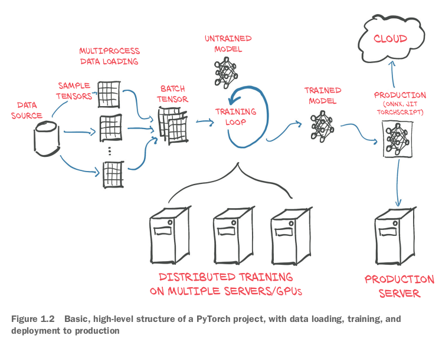

`torch.nn.parallel.Distributed-DataParallel` and the `torch.distributed` submodule can be employed to use the additional hardware, if necessary.

Using TorchScript, PyTorch can serialize a model into a set of instructions that can be invoked independently from Python: say, from C++ programs or on mobile devices.

[DAWNBench](https://dawn.cs.stanford.edu/benchmark/index.html)

- Provides benchmarks on training time and cloud computing costs related to common deep learing tasks on publicly available datasets.

[Google Colaboratory](https://colab.research.google.com)

- Cloud platform, offer GPU-enabled Jupyter Notebooks with PyTorch preinstalled (free quota)

**We are going to be making heavy use of Jupyter Notebooks for our example code**

Full working code for all listings from the book can be found at:

- The book's website
- Our [repository in github](https://github.com/deep-learning-with-pytorch/dlwpt-code)